# Basic model of evolutionary rescue in discrete time

Jan Leuenberger & Safeeya Ramis

2026-10-27

# 1. Introduction

This report documents a stochastic simulation of **evolutionary rescue** in discrete time, based on the model of Orr & Unckless introduced in the practical. We extended the basic model with **habitat fragmentation**: at a chosen generation (`split_time`) the population is split into two separate and isolated habitats (B and C) of varieng sizes, each with its own carrying capacity.

**Biological scenario**

- A haploid population consists of wild-type individuals (**a**) and, possibly, mutant individuals (**A**).
- A sudden environmental change makes the wild type unfit: it **declines** at rate `decay_rate`.
- The mutant is **beneficial** (advantage `sel_coeff`) and can grow in the new environment, but it is initially rare or absent. If absent, it has to arise by mutation from the wild type.
- The population is **rescued** if the mutant spreads before the wild type (and with it the whole population) goes extinct.
- The Habitat gets seperatated at a defined time called **split_time**.Individuals are randomly distributed, each habitat has a smaller carrying capacity, and both then evolve independently.

**Research Questions**

- Is evolutionary rescue possible in the Fragmented habitats?
  - What is the impact of split_time on ER?
  - What is the impact of the habitat porportions on ER?

## 1.1 Overview of the code

1. `simulate_one_gen()`: simulates **one generation** (reproduction with logistic growth + mutation) for one habitat.
2. `simulate_pop()`: runs a **full simulation**: one habitat until `split_time`, then two habitats (B and C) afterwards.
3. Plot functions (`plot_split()`, `plot_habitat()`, `plot_habitats()`): visualise a single simulation run.
4. `run_scenarios()` and `to_long()`: repeat the simulation many times for different parameter values and summaries the **rescue probability**.
5. Three analyses: split time varies, habitat proportion varies, and both.

## 1.2 Parameters and variables

| Name | Meaning |
| --- | --- |
| `N_a`, `N_A` | current size of the wild-type / mutant population (change over time) |
| `N_init_a`, `N_init_A` | initial sizes of wild type (positive integer) and mutant (non-negative integer) |
| `decay_rate` | detrimental effect of the environment on the wild type (> 0 so that extinction is possible) |
| `sel_coeff` | selective advantage of the mutant (should be > `decay_rate` to allow rescue) |
| `mut_rate` | mutation rate from wild type to mutant (> 0 and small) |
| `t_max` | maximum number of generations simulated (a setting, not a model parameter) |
| `split_time` | generation at which the fragmentation happens (integer > 0) |
| `split_ratio` | probability with which each individual is assigned to habitat B at the split (between 0 and 1) |
| `habitat_prop` | share of the total carrying capacity given to habitat B (between 0 and 1); habitat C gets `1 - habitat_prop` |
| `K` | carrying capacity of the original (unsplit) habitat; limits growth and is divided among B and C in the same proportions as the habitats |

## Simulating evolutionary rescue in discrete time

In this notebook, we are implementing simulations of evolutionary rescue by a single mutation in discrete time, as discussed and analyzed in the work by Orr & Unckless. The model is as follows: a haploid population starts with a given number of wild-type and mutant individuals. Because of a sudden environmental change, the wild type is unfit and declines in the new environment. The mutant is beneficial and can survive and expand in the new environment, but it starts at a low (or zero) frequency in the total population. In order to rescue the population, it has to outcompete the wild type. If the mutant is not present at time 0, it has to appear through mutation and then spread in the population before extinction occurs.

## Simulate one generation of population size change

We want to observe the numbers of wild-type and mutant individuals over time. As first step, we simulate one generation of the population. At time $t$, the population has $N_a$ wild-type individuals and $N_A$ mutant individuals. First, these reproduce. This is modeled by drawing a Poisson random variable according to the expected absolute number $N_a \cdot (1-r)$ of wild-type individuals, where $r$ is the decay rate of the wild type, and $N_A \cdot (1-r+s)$ of mutant individuals, where $s$ is the selective advantage of the mutant over the wild time. Then mutation from $a$ to $A$ occurs as a Poisson random variable according to the given mutation rate. This defines the composition of the population at time $t+1$.

1. **Expected offspring (logistic growth).** Without competition, the per-capita growth rates are
   - wild type: $\rho_a = -r$ (negative, so the type declines), with $r$ = `decay_rate`
   - mutant: $\rho_A = s - r$ (positive if $s > r$), with $s$ = `sel_coeff`

   Competition is added by a **density-dependent term**: the growth factor of each type is reduced by $\rho_A \cdot N_{tot}/K$. The expected number of offspring is therefore

   $$\bar N_a =
   N_a\,\max\!\left(0,\;1+\rho_a-\rho_A \tfrac{N_{tot}}{K}\right), \qquad
   \bar N_A = N_A\,\max\!\left(0,\;1+\rho_A-\rho_A
   \tfrac{N_{tot}}{K}\right)$$

   When $N_{tot}$ approaches $K$, the mutant’s growth factor approaches 1 (population stays constant) and the wild type keeps declining. When $N_{tot} > K$ the mutant would shrink back towards $K$. The `max(0, ...)` prevents negative expected values, which `rpois()` cannot handle.
2. **Demographic stochasticity.** The actual number of offspring is drawn from a **Poisson distribution** whose mean is the expected value above. This is what makes every run different.
3. **Mutation.** Of the wild-type offspring, a Poisson-distributed number (mean `offsp_a * mut_rate`) mutates to type A. These are subtracted from the wild type and added to the mutants.

The function returns a vector `c(N_a_new, N_A_new)`.

```r
simulate_one_gen <- function(N_a, N_A, decay_rate, sel_coeff, mut_rate, K) {

   # total population size and per-capita growth rates without competition
  N_tot <- N_a + N_A
  rho_a <- -decay_rate
  rho_A <- sel_coeff - decay_rate
  # logistic growth: crowding reduces the growth of both types equally (set to 0 if negative)
  mean_a <- N_a * max(0, 1 + rho_a - rho_A * N_tot / K)
  mean_A <- N_A * max(0, 1 + rho_A - rho_A * N_tot / K)
  # draw offspring according to Poisson distribution
  offsp_a <- rpois(1, mean_a)
  offsp_A <- rpois(1, mean_A)
  # draw new mutants according to Poisson distribution
  mut_a_to_A <- rpois(1, offsp_a * mut_rate)
  # determine new population sizes of wild type and mutant
  N_a_new <- offsp_a - mut_a_to_A
  N_A_new <-  offsp_A + mut_a_to_A

  return(c(N_a_new, N_A_new))
}
# Test the function
#print(simulate_one_gen(100,0,0.1,0.2,0.001,1000))
```

```r
simulate_pop <- function(N_init_a, N_init_A, decay_rate, sel_coeff, mut_rate, t_max, K, habitat_prop, split_ratio, split_time) {
  # Create the vector in which to save the results
  pop_vector <- c(N_init_a, N_init_A)
  # initiate the variables
  pop_new <- c(N_init_a, N_init_A)

  # Create the vectors for the new habitats
  pop_vector_B <- NULL
  pop_vector_C <- NULL

  # run the simulation until generation t_max
  for (i in 1:t_max) {

     # Time when the fragmentation occur
    if (i == split_time + 1) {

    # Create the new habitats (creating new K)
    K_B <- K * habitat_prop
    K_C <- K * (1 - habitat_prop)

    #create the ratio of the splitting
    split_ratio_B <- split_ratio
    split_ratio_C <- (1 - split_ratio_B)
    # print(split_ratio_B)
    # print(split_ratio_C)
    # Distribute individuals  randomly to the habitat B
    n_B_a <- rbinom(1, pop_new[1], split_ratio_B)
    n_B_A <- rbinom(1, pop_new[2], split_ratio_B)

    # Distribute individuals randomly to the habitat C
    n_C_a <- pop_new[1] - n_B_a
    n_C_A <- pop_new[2] - n_B_A

    # Calculate the new populatins for B an C
    pop_new_B <- simulate_one_gen(n_B_a, n_B_A, decay_rate, sel_coeff, mut_rate, K_B)
    pop_new_C <- simulate_one_gen(n_C_a, n_C_A, decay_rate, sel_coeff, mut_rate, K_C)

    # add the new population sizes to the output vector
    pop_vector_B <- rbind(pop_vector_B,pop_new_B)
    pop_vector_C <- rbind(pop_vector_C,pop_new_C)

    }

    if (i > split_time + 1) {

    pop_new_B <- simulate_one_gen(
      pop_new_B[1], pop_new_B[2],
      decay_rate, sel_coeff, mut_rate,K_B
    )

    pop_new_C <- simulate_one_gen(
      pop_new_C[1], pop_new_C[2],
      decay_rate, sel_coeff, mut_rate,K_C
    )

    # Save the results for each generation
    pop_vector_B <- rbind(pop_vector_B, pop_new_B)
    pop_vector_C <- rbind(pop_vector_C, pop_new_C)

    # define the row and column names of the output vector
    rownames(pop_vector_B) <- (0:t_max)[1:length(pop_vector_B[,1])]
    rownames(pop_vector_C) <- (0:t_max)[1:length(pop_vector_C[,1])]
    colnames(pop_vector_B) <- c("a","A")
    colnames(pop_vector_C) <- c("a","A")

    }

    # Continue simulating habitat A only until split_time
if (i <= split_time) {

    # redefine the current population one generation later
    pop_new <- simulate_one_gen(pop_new[1],pop_new[2], decay_rate, sel_coeff, mut_rate,K)
    # add the new population sizes to the output vector
    pop_vector <- rbind(pop_vector,pop_new)
    # condition to stop the simulation before t_max: either the population exceeds 2 times the original population size, or it goes extinct
    if (pop_new[1]+pop_new[2]>=2*(N_init_a+ N_init_A) | pop_new[1]+pop_new[2]==0) break
}

 }
  # define the row and column names of the output vector
  rownames(pop_vector) <- (0:t_max)[1:length(pop_vector[,1])] # note that the vector has to be cut if the simulation stopped early
  colnames(pop_vector) <- c("a","A")

  # Data frames
    pop_vector_df <- as.data.frame(pop_vector)
    pop_vector_B_df <- as.data.frame(pop_vector_B)
    pop_vector_C_df <- as.data.frame(pop_vector_C)
  # return all three population vectors separately
  return(list(main = pop_vector_df, B = pop_vector_B_df, C = pop_vector_C_df))


}
```

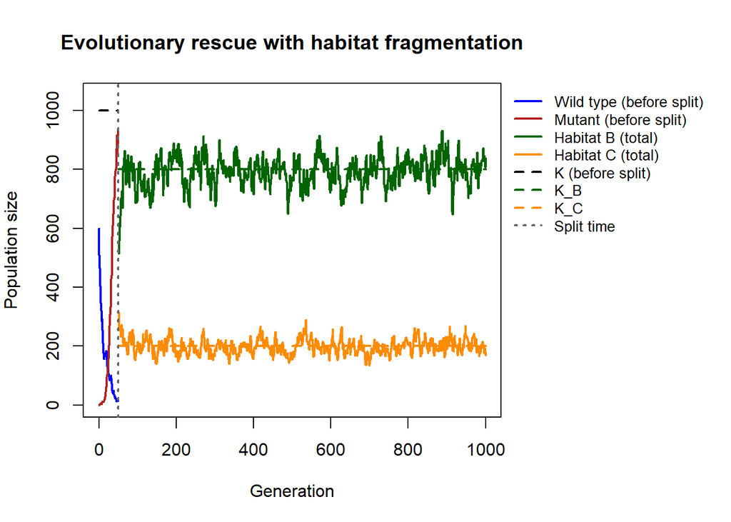

```r
# ============================================================
# Plot functions for the evolutionary rescue simulation
# with habitat fragmentation
# ============================================================

# ---- 1. Overview plot: wild type and mutant before the split,
#         total of habitats B and C after the split, legend outside ----
plot_split <- function(output, K, habitat_prop, split_time, xlim_max = NULL) {

  main <- output$main
  B    <- output$B
  C    <- output$C

  K_B <- K * habitat_prop
  K_C <- K * (1 - habitat_prop)

  # population sizes before the split (wild type and mutant separately)
  wt_main  <- main$a
  mut_main <- main$A

  # total population sizes after the split
  tot_B <- B$a + B$A
  tot_C <- C$a + C$A

  # generation numbers
  gen_main <- 0:(length(wt_main) - 1)
  gen_B    <- split_time + seq_along(tot_B)
  gen_C    <- split_time + seq_along(tot_C)

  # axis ranges
  x_max <- if (is.null(xlim_max)) max(c(gen_main, gen_B)) else xlim_max
  y_max <- max(c(K, wt_main, mut_main, tot_B, tot_C), na.rm = TRUE)

  # make room on the right for the legend, restore settings afterwards
  old_par <- par(mar = c(5, 4, 4, 11))
  on.exit(par(old_par))

  plot(NA, xlim = c(0, x_max), ylim = c(0, y_max * 1.05),
       xlab = "Generation", ylab = "Population size",
       main = "Evolutionary rescue with habitat fragmentation")

  # carrying capacities: K only until the split, then K_B and K_C
  segments(0, K, split_time, K, col = "black", lty = 2, lwd = 2)
  segments(split_time, K_B, x_max, K_B, col = "darkgreen",  lty = 2, lwd = 2)
  segments(split_time, K_C, x_max, K_C, col = "darkorange", lty = 2, lwd = 2)

  # before the split: wild type and mutant
  lines(gen_main, wt_main,  col = "blue",      lwd = 2)
  lines(gen_main, mut_main, col = "firebrick", lwd = 2)

  # after the split: total of habitat B and C
  if (length(tot_B) > 0) lines(gen_B, tot_B, col = "darkgreen",  lwd = 2)
  if (length(tot_C) > 0) lines(gen_C, tot_C, col = "darkorange", lwd = 2)

  # split time
  abline(v = split_time, col = "grey40", lty = 3, lwd = 2)

  # legend outside, at the top right corner of the plot region
  legend(x = par("usr")[2], y = par("usr")[4], xpd = TRUE, bty = "n",
         xjust = 0, yjust = 1, cex = 0.85,
         legend = c("Wild type (before split)", "Mutant (before split)",
                    "Habitat B (total)", "Habitat C (total)",
                    "K (before split)", "K_B", "K_C", "Split time"),
         col = c("blue", "firebrick", "darkgreen", "darkorange",
                 "black", "darkgreen", "darkorange", "grey40"),
         lty = c(1, 1, 1, 1, 2, 2, 2, 3), lwd = 2)
}

# ---- 2. Single habitat panel (used for B and C) ----
plot_habitat <- function(df, K_hab, split_time, title, col_tot, xlim_max = NULL) {

  if (is.null(df) || nrow(df) == 0) {
    plot.new()
    title(main = paste(title, "- no data (population ended before the split)"))
    return(invisible(NULL))
  }

  gens  <- split_time + seq_len(nrow(df))
  tot   <- df$a + df$A
  x_max <- if (is.null(xlim_max)) max(gens) else xlim_max
  y_max <- max(c(K_hab, tot), na.rm = TRUE)

  plot(NA, xlim = c(split_time, x_max), ylim = c(0, y_max * 1.05),
       xlab = "Generation", ylab = "Population size", main = title)

  abline(h = K_hab, col = col_tot, lty = 2, lwd = 2)       # K of this habitat
  abline(v = split_time, col = "grey40", lty = 3, lwd = 2) # split time

  lines(gens, tot,  col = col_tot,     lwd = 2)  # total
  lines(gens, df$a, col = "blue",      lwd = 2)  # wild type
  lines(gens, df$A, col = "firebrick", lwd = 2)  # mutant



  legend(x = par("usr")[2], y = par("usr")[4], xpd = TRUE, bty = "n",
         xjust = 0, yjust = 1, cex = 0.85,
         legend = c("Total", "Wild type (a)", "Mutant (A)", "K", "Split time"),
         col = c(col_tot, "blue", "firebrick", col_tot, "grey40"),
         lty = c(1, 1, 1, 2, 3), lwd = 2)

  ##adding the starting population
    legend(x = par("usr")[2], y = par("usr")[4], xpd = TRUE, bty = "n",
         xjust = 0, yjust = 1, cex = 0.85,
         legend = c("Total",
                    paste0("Wild type (a), start ", df$a[1]),
                    paste0("Mutant (A), start ", df$A[1]),
                    "K", "Split time"),
         col = c(col_tot, "blue", "firebrick", col_tot, "grey40"),
         lty = c(1, 1, 1, 2, 3), lwd = 2)
}

# ---- 3. Two panels: habitat B on top, habitat C below ----
plot_habitats <- function(output, K, habitat_prop, split_time, xlim_max = NULL) {

  K_B <- K * habitat_prop
  K_C <- K * (1 - habitat_prop)

  # two panels stacked, with room on the right for the legends
  old_par <- par(mfrow = c(2, 1), mar = c(4, 4, 3, 11))
  on.exit(par(old_par))

  plot_habitat(output$B, K_B, split_time, "Habitat B", "darkgreen",  xlim_max)
  plot_habitat(output$C, K_C, split_time, "Habitat C", "darkorange", xlim_max)
}

# ============================================================
# Usage
# (simulate_one_gen and simulate_pop must be defined first)
# ============================================================
max_gen      <- 1000
K            <- 1000
habitat_prop <- 0.8
split_time   <- 50
split_ratio  <- 0.5

output <- simulate_pop(600, 0, 0.01, 0.2, 0.001, max_gen, K,
                       habitat_prop, split_ratio , split_time)

# overview plot
plot_split(output, K = K, habitat_prop = habitat_prop, split_time = split_time)
```

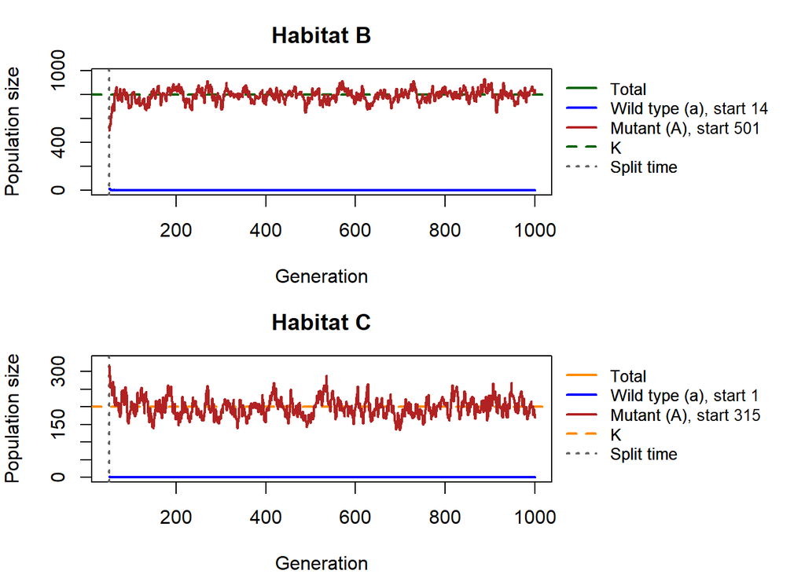

```r
# panels for habitat B and C
plot_habitats(output, K = K, habitat_prop = habitat_prop, split_time = split_time)
```

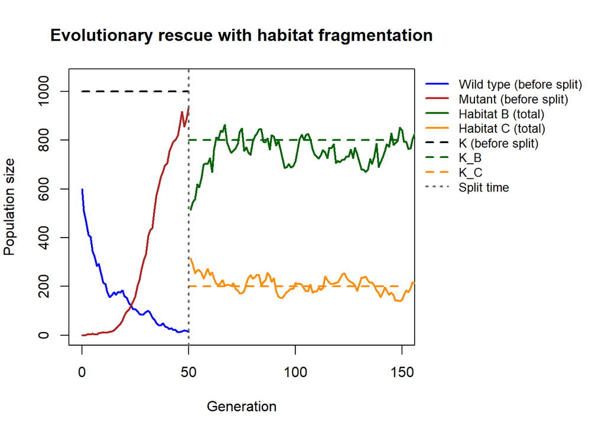

```r
# zoomed in on the first 150 generations
plot_split(output, K = K, habitat_prop = habitat_prop,
           split_time = split_time, xlim_max = 150)
```

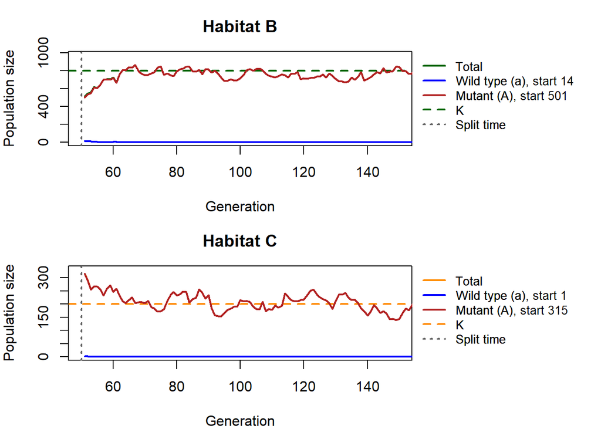

```r
plot_habitats(output, K = K, habitat_prop = habitat_prop,
              split_time = split_time, xlim_max = 150)
```